# 大作业

安装numpy pandas matplotlib seaborn scikit-learn 这五个库

```python
pip install numpy pandas matplotlib seaborn scikit-learn
```

导入必要的库

```python
import numpy as np
import pandas as pd
import matplotlib.pyplot as plt
import seaborn as sns
from sklearn.model_selection import train_test_split, cross_val_score, GridSearchCV
from sklearn.linear_model import LogisticRegression
from sklearn.preprocessing import StandardScaler
from sklearn.metrics import (roc_curve, auc, confusion_matrix,
                             classification_report, accuracy_score)
from sklearn.feature_selection import SelectKBest, f_classif
```

设置Matplotlib的绘图样式为seaborn风格的第0.8版样式

```python
# 设置绘图风格
plt.style.use('seaborn-v0_8')
%matplotlib inline
```

数据探索：读取数据并查看基本结构。 数据清洗：删除无关信息，避免噪声干扰模型。 数据转换：将分类标签转换为数值型，适配模型输入。 数据准备：分离特征与标签，为模型训练做准备。 数据洞察：通过类别分布了解数据特性，指导后续策略（如平衡采样）。

```python
# 1. 加载数据
data = pd.read_csv('data.csv')  # 请确保文件路径正确

# 查看数据前几行
print(data.head())

# 2. 数据预处理
# 删除不必要的列
data = data.drop(['id', 'Unnamed: 32'], axis=1)

# 将诊断结果转换为二进制标签 (M=1, B=0)
data['diagnosis'] = data['diagnosis'].map({'M':1, 'B':0})

# 分离特征和标签
X = data.drop('diagnosis', axis=1)
y = data['diagnosis']

# 查看类别分布
print("\n类别分布:")
print(y.value_counts())
```

```
         id diagnosis  radius_mean  texture_mean  perimeter_mean  area_mean  \
0    842302         M        17.99         10.38          122.80     1001.0
1    842517         M        20.57         17.77          132.90     1326.0
2  84300903         M        19.69         21.25          130.00     1203.0
3  84348301         M        11.42         20.38           77.58      386.1
4  84358402         M        20.29         14.34          135.10     1297.0

   smoothness_mean  compactness_mean  concavity_mean  concave points_mean  \
0          0.11840           0.27760          0.3001              0.14710
1          0.08474           0.07864          0.0869              0.07017
2          0.10960           0.15990          0.1974              0.12790
3          0.14250           0.28390          0.2414              0.10520
4          0.10030           0.13280          0.1980              0.10430

   ...  texture_worst  perimeter_worst  area_worst  smoothness_worst  \
0  ...          17.33           184.60      2019.0            0.1622
1  ...          23.41           158.80      1956.0            0.1238
2  ...          25.53           152.50      1709.0            0.1444
3  ...          26.50            98.87       567.7            0.2098
4  ...          16.67           152.20      1575.0            0.1374

   compactness_worst  concavity_worst  concave points_worst  symmetry_worst  \
0             0.6656           0.7119                0.2654          0.4601
1             0.1866           0.2416                0.1860          0.2750
2             0.4245           0.4504                0.2430          0.3613
3             0.8663           0.6869                0.2575          0.6638
4             0.2050           0.4000                0.1625          0.2364

   fractal_dimension_worst  Unnamed: 32
0                  0.11890          NaN
1                  0.08902          NaN
2                  0.08758          NaN
3                  0.17300          NaN
4                  0.07678          NaN

[5 rows x 33 columns]

类别分布:
diagnosis
0    357
1    212
Name: count, dtype: int64
```

特征预处理：标准化特征以提升模型训练效率和稳定性。 数据划分：分层抽样确保训练集和测试集的类别分布合理，避免评估偏差。 模型初始化：设置可复现的随机种子和合理的迭代次数。 初步评估：通过交叉验证快速获取模型基准性能，为后续优化提供参考。

```python
# 3. 特征缩放
scaler = StandardScaler()
X_scaled = scaler.fit_transform(X)

# 4. 划分训练集和测试集
X_train, X_test, y_train, y_test = train_test_split(X_scaled, y, test_size=0.3,
                                                    random_state=42, stratify=y)

# 5. 创建逻辑回归模型
logreg = LogisticRegression(random_state=42, max_iter=1000)

# 6. 交叉验证
cv_scores = cross_val_score(logreg, X_train, y_train, cv=5, scoring='accuracy')
```

可视化分析：通过箱线图直观展示交叉验证结果的分布，帮助判断模型稳定性。 量化评估：计算均值和标准差，用具体指标描述模型性能。 工程化准备：导入 Pipeline 为后续构建更规范的模型训练流程做铺垫。

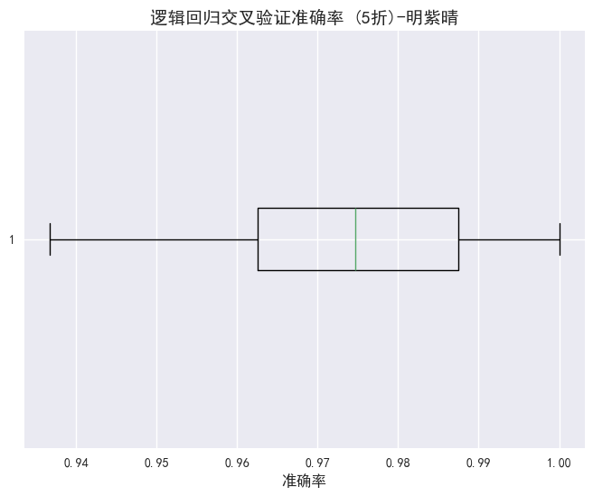

```
交叉验证平均准确率: 0.9723 ± 0.0218
```

```python
# 绘制交叉验证结果箱线图
plt.rcParams['font.sans-serif'] = ['SimHei']  # 使用黑体
plt.rcParams['axes.unicode_minus'] = False  # 解决负号显示问题
plt.figure(figsize=(8, 6))
plt.boxplot(cv_scores, vert=False)
plt.title('逻辑回归交叉验证准确率 (5折)-明紫晴', fontsize=14)
plt.xlabel('准确率', fontsize=12)
plt.savefig('logistic_cross_validation.png', bbox_inches='tight', dpi=300)
plt.show()

print(f"交叉验证平均准确率: {cv_scores.mean():.4f} ± {cv_scores.std():.4f}")
from sklearn.pipeline import Pipeline

student_name = "明紫晴"
```

自动化调参：通过 Pipeline 和 GridSearchCV 实现标准化和模型训练的一体化调优，避免手动调参的低效和偏差。 系统性搜索：在广泛的超参数空间中进行穷举搜索，找到最优参数组合。 可视化决策：通过图表直观展示不同超参数对模型性能的影响，支持后续模型优化。

[output not shown]

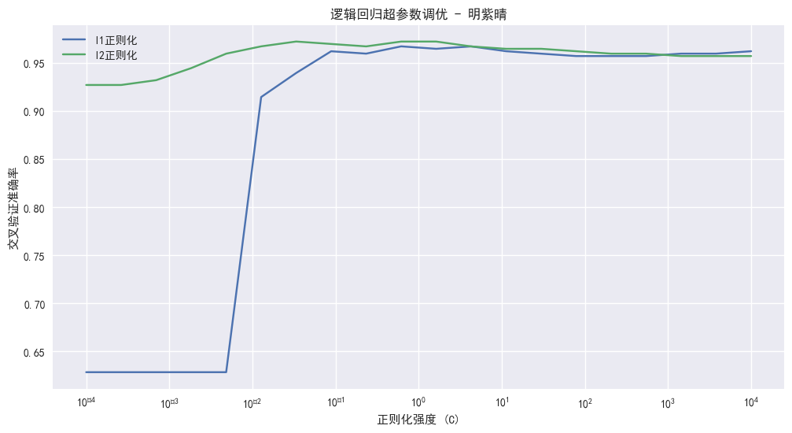

```python
# 7. 超参数调优
pipeline = Pipeline([
    ('scaler', StandardScaler()),
    ('lr', LogisticRegression(max_iter=10000, random_state=42))
])

param_grid = {
    'lr__C': np.logspace(-4, 4, 20),
    'lr__penalty': ['l1', 'l2'],
    'lr__solver': ['liblinear']
}

grid_search = GridSearchCV(pipeline, param_grid, cv=5, scoring='accuracy', n_jobs=-1)
grid_search.fit(X_train, y_train)
results = pd.DataFrame(grid_search.cv_results_)

# 绘制超参数调优过程图并添加姓名
plt.figure(figsize=(12, 6))
for penalty in ['l1', 'l2']:
    subset = results[results['param_lr__penalty'] == penalty]
    plt.plot(subset['param_lr__C'], subset['mean_test_score'],
             label=f'{penalty}正则化')

plt.xscale('log')
plt.xlabel('正则化强度 (C)')
plt.ylabel('交叉验证准确率')
plt.title(f'逻辑回归超参数调优 - {student_name}')  # 使用f-string添加姓名
plt.legend()
plt.grid(True)
plt.savefig('logistic_hyperparameter_tuning.png', dpi=300, bbox_inches='tight')
plt.show()
```

模型选择：基于交叉验证结果，挑选最优超参数组合的模型。 完整训练：使用全部训练数据训练最终模型，充分利用数据信息。 预测评估：在测试集上生成预测结果，并通过准确率量化模型性能。

```python
best_logreg = grid_search.best_estimator_
best_logreg.fit(X_train, y_train)
y_pred = best_logreg.predict(X_test)
y_prob = best_logreg.predict_proba(X_test)[:, 1]  # 阳性类别的概率
accuracy = accuracy_score(y_test, y_pred)
print(f"\n测试集准确率: {accuracy:.4f}")
```

```
测试集准确率: 0.9883
```

性能评估逻辑：ROC 曲线通过展示不同阈值下 FPR 与 TPR 的权衡关系，全面评估模型的分类能力；AUC 值则用单一指标量化模型对正负样本的排序能力。 适用场景：尤其适合类别不平衡数据（如本实验中良性样本多于恶性样本），避免仅用准确率导致的评估偏差。 结果解读：若 ROC 曲线接近左上角且 AUC≈1，说明模型性能优异；若接近对角线，则模型效果接近随机猜测。

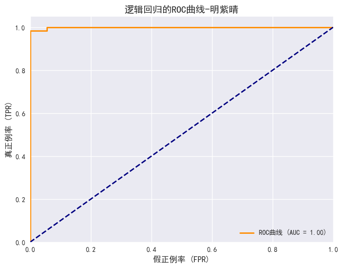

```python
# 10. 绘制ROC曲线

fpr, tpr, thresholds = roc_curve(y_test, y_prob)
roc_auc = auc(fpr, tpr)

plt.figure(figsize=(8, 6))
plt.plot(fpr, tpr, color='darkorange', lw=2,
         label=f'ROC曲线 (AUC = {roc_auc:.2f})')
plt.plot([0, 1], [0, 1], color='navy', lw=2, linestyle='--')
plt.xlim([0.0, 1.0])
plt.ylim([0.0, 1.05])
plt.xlabel('假正例率 (FPR)', fontsize=12)
plt.ylabel('真正例率 (TPR)', fontsize=12)
plt.title('逻辑回归的ROC曲线-明紫晴', fontsize=14)
plt.legend(loc="lower right")
plt.savefig('logistic_roc_curve.png', bbox_inches='tight', dpi=300)
plt.show()
```

评估价值：混淆矩阵通过分解四种分类结果，揭示模型在不同类别上的表现。在医疗场景中，FP（误诊）和 FN（漏诊）的代价不同，需特别关注。 业务洞察：

对角线值（TN 和 TP）越高，模型整体准确性越好。 非对角线值（FP 和 FN）反映错误类型： FP 高：模型倾向于过度诊断（假警报多）。 FN 高：模型倾向于漏诊（更危险，尤其在医疗场景）。

后续优化：若 FN 过高，可调整分类阈值（如降低阈值使模型更敏感），或采用代价敏感学习（对 FN 赋予更高权重）。

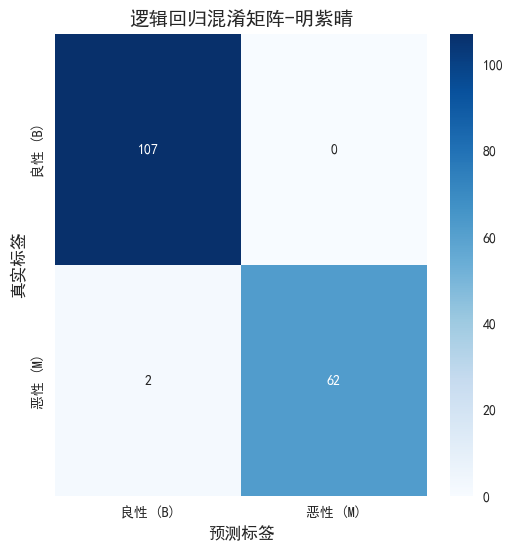

```python
# 11. 绘制混淆矩阵
cm = confusion_matrix(y_test, y_pred)

plt.figure(figsize=(6, 6))
sns.heatmap(cm, annot=True, fmt='d', cmap='Blues',
            xticklabels=['良性 (B)', '恶性 (M)'],
            yticklabels=['良性 (B)', '恶性 (M)'])
plt.xlabel('预测标签', fontsize=12)
plt.ylabel('真实标签', fontsize=12)
plt.title('逻辑回归混淆矩阵-明紫晴', fontsize=14)
plt.savefig('logistic_confusion_matrix.png', bbox_inches='tight', dpi=300)
plt.show()
```

特征筛选依据：逻辑回归系数的绝对值反映了特征对分类决策的影响程度，绝对值越大，特征越重要。 业务价值：

特征解释：例如，在医疗诊断中，texture_worst（最差纹理）和radius_se（半径标准误差）等特征的高重要性，可能提示医生在临床判断时应重点关注这些指标。 特征工程：可根据重要性删除低贡献特征，简化模型或减少噪声。

局限性：

系数重要性仅适用于线性关系，若特征与类别存在非线性关系，需结合非线性模型（如随机森林）进行分析。 特征间的多重共线性可能导致系数不稳定，需预先处理相关性高的特征。

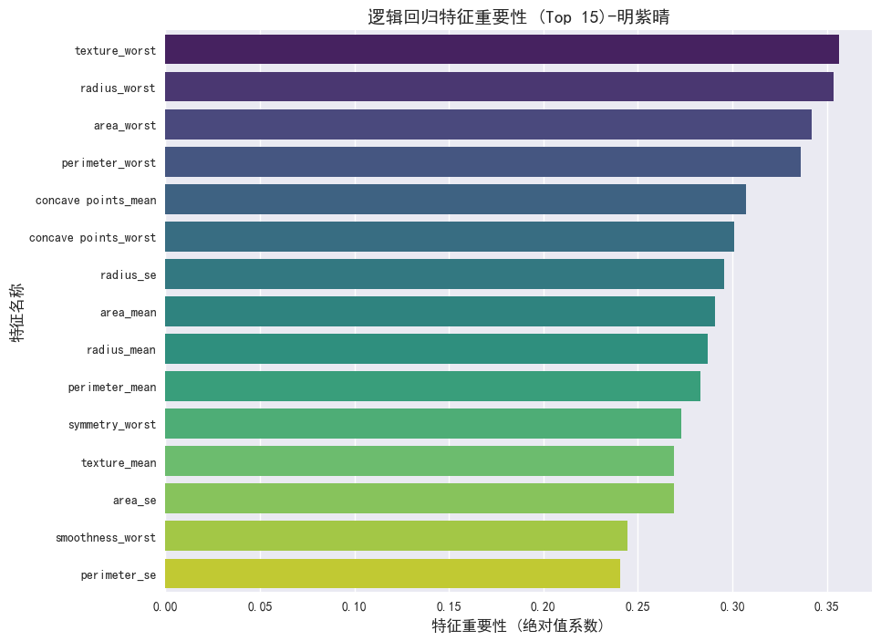

```python
# 12. 特征重要性分析
# 由于逻辑回归的系数可以解释为特征重要性
feature_importance = pd.DataFrame({
    'Feature': X.columns,
    'Importance': np.abs(best_logreg.named_steps['lr'].coef_[0])  # 正确访问
}).sort_values('Importance', ascending=False)

plt.figure(figsize=(10, 8))
sns.barplot(x='Importance', y='Feature', data=feature_importance.head(15), hue='Feature', palette='viridis', legend=False)
plt.title('逻辑回归特征重要性 (Top 15)-明紫晴', fontsize=14)
plt.xlabel('特征重要性 (绝对值系数)', fontsize=12)
plt.ylabel('特征名称', fontsize=12)
plt.savefig('logistic_feature_importance.png', bbox_inches='tight', dpi=300)
plt.show()
```

通过打印分类报告（Classification Report），从多个维度全面评估逻辑回归模型在测试集上的分类性能，尤其是不同类别（良性 / 恶性）的预测质量。

```python
# 打印分类报告
print("\n分类报告:")
print(classification_report(y_test, y_pred, target_names=['良性 (B)', '恶性 (M)']))
```

```
分类报告:
              precision    recall  f1-score   support

      良性 (B)       0.98      1.00      0.99       107
      恶性 (M)       1.00      0.97      0.98        64

    accuracy                           0.99       171
   macro avg       0.99      0.98      0.99       171
weighted avg       0.99      0.99      0.99       171
```